# Social Media Assigment

Shubham Bhargava 2024-04-25

### Social Media Data Analysis

#### Project Overview:

This project investigates the effects of social media use on our sleep, productivity, and mood. We’re examining data to determine whether there’s a relationship between users’ emotional states or sleep quality and the amount of time they spend on social media sites like Instagram or Twitter. The objective is to determine whether various online behaviors are associated with better or worse feelings and what lessons can be drawn from that.

#### Data Collection

The variables included in this dataset

- character
- Instagram
- LinkedIn
- SnapChat
- Twitter
- Whatsapp/Wechat
- youtube
- OTT
- Reddit
- Trouble_falling_asleep
- Mood Productivity
- Tired waking up in morning
- How you felt the entire week?

#### Dependent Variables

```
- Mood Productivity
- Trouble falling asleep
```

#### Independent Variables

```
- Instagram
- LinkedIn
- SnapChat
- Twitter
- Whatsapp/Wechat
- youtube
- OTT
- Reddit
```

#### Data Collection

```r
library(readxl)
library(dplyr)
library(FactoMineR)
library(factoextra)
```

```r
library(ggplot2)
library(ggfortify)
library(MASS)
library(ggrepel)
library(stats)
library(scatterplot3d)
library(cluster)
library(psych)
library(car)
library(GGally)
library(ROCR)
library(pROC)
library(DataExplorer)
social_media <- read_excel("social_media_cleaned.xlsx")
social_media_numeric <- select_if(social_media, is.numeric)

print(social_media)
```

```
## # A tibble: 21 × 13
##    character Instagram LinkedIn SnapChat Twitter `Whatsapp/Wechat` youtube   OTT
##    <chr>         <dbl>    <dbl>    <dbl>   <dbl>             <dbl>   <dbl> <dbl>
##  1 masinl        3.5      4        1       5                  1       2.5   14.5
##  2 peace         7.73     5.2      3.68    0                  4.18    4.25   0
##  3 Patty         3.77     7        0.533   0                  9.83    1.85   2
##  4 Bunny         5.38     5.32     1.3     0                  5.3     2      2
##  5 tl868        12        0.583    0       0.667              3       3.5    2
##  6 drphy         2.33     7        0.467   0                 12       7      3
##  7 trave         5.37     4        0       0                  6       3      0
##  8 19!@s         7        4        3       0                 10       2      3
##  9 yh2020        8.65    10        3.83    0                  6.15    4      3
## 10 ds2134        0.167    0        0       0                  1       3      0
## # ℹ 11 more rows
## # ℹ 5 more variables: Reddit <dbl>, Trouble_falling_asleep <dbl>,
## #   `Mood Productivity` <dbl>, `Tired waking up in morning` <dbl>,
## #   `How you felt the entire week?` <dbl>
```

```r
head(social_media)
```

```
## # A tibble: 6 × 13
##   character Instagram LinkedIn SnapChat Twitter `Whatsapp/Wechat` youtube   OTT
##   <chr>         <dbl>    <dbl>    <dbl>   <dbl>             <dbl>   <dbl> <dbl>
## 1 masinl         3.5     4        1       5                  1       2.5   14.5
## 2 peace          7.73    5.2      3.68    0                  4.18    4.25   0
## 3 Patty          3.77    7        0.533   0                  9.83    1.85   2
## 4 Bunny          5.38    5.32     1.3     0                  5.3     2      2
## 5 tl868         12       0.583    0       0.667              3       3.5    2
## 6 drphy          2.33    7        0.467   0                 12       7      3
## # ℹ 5 more variables: Reddit <dbl>, Trouble_falling_asleep <dbl>,
## #   `Mood Productivity` <dbl>, `Tired waking up in morning` <dbl>,
## #   `How you felt the entire week?` <dbl>
```

```r
summary(social_media)
```

```
##   character           Instagram          LinkedIn         SnapChat
##  Length:21          Min.   : 0.1667   Min.   : 0.000   Min.   : 0.0000
##  Class :character   1st Qu.: 3.7667   1st Qu.: 1.917   1st Qu.: 0.0000
##  Mode  :character   Median : 5.3833   Median : 3.917   Median : 0.5333
##                     Mean   : 5.9230   Mean   : 3.624   Mean   : 1.9738
##                     3rd Qu.: 7.0000   3rd Qu.: 5.000   3rd Qu.: 1.8667
##                     Max.   :15.0167   Max.   :10.000   Max.   :14.8667
##     Twitter       Whatsapp/Wechat     youtube           OTT
##  Min.   :0.0000   Min.   : 1.000   Min.   :0.000   Min.   : 0.000
##  1st Qu.:0.0000   1st Qu.: 3.667   1st Qu.:2.000   1st Qu.: 0.000
##  Median :0.0000   Median : 6.000   Median :3.000   Median : 1.683
##  Mean   :0.5802   Mean   : 6.430   Mean   :2.973   Mean   : 2.361
##  3rd Qu.:0.2667   3rd Qu.: 8.917   3rd Qu.:4.000   3rd Qu.: 2.467
##  Max.   :5.0000   Max.   :15.350   Max.   :7.000   Max.   :14.500
##      Reddit       Trouble_falling_asleep Mood Productivity
##  Min.   :0.0000   Min.   :0.0000         Min.   :0.0000
##  1st Qu.:0.0000   1st Qu.:0.0000         1st Qu.:1.0000
##  Median :0.0000   Median :0.0000         Median :1.0000
##  Mean   :0.5243   Mean   :0.3333         Mean   :0.9524
##  3rd Qu.:0.0000   3rd Qu.:1.0000         3rd Qu.:1.0000
##  Max.   :7.0000   Max.   :1.0000         Max.   :1.0000
##  Tired waking up in morning How you felt the entire week?
##  Min.   :0.0000             Min.   :2.000
##  1st Qu.:0.0000             1st Qu.:3.000
##  Median :0.0000             Median :3.000
##  Mean   :0.3333             Mean   :3.429
##  3rd Qu.:1.0000             3rd Qu.:4.000
##  Max.   :1.0000             Max.   :5.000
```

```r
str(social_media)
```

```
## tibble [21 × 13] (S3: tbl_df/tbl/data.frame)
##  $ character                    : chr [1:21] "masinl" "peace" "Patty" "Bunny" ...
##  $ Instagram                    : num [1:21] 3.5 7.73 3.77 5.38 12 ...
##  $ LinkedIn                     : num [1:21] 4 5.2 7 5.317 0.583 ...
##  $ SnapChat                     : num [1:21] 1 3.683 0.533 1.3 0 ...
##  $ Twitter                      : num [1:21] 5 0 0 0 0.667 ...
##  $ Whatsapp/Wechat              : num [1:21] 1 4.18 9.83 5.3 3 ...
##  $ youtube                      : num [1:21] 2.5 4.25 1.85 2 3.5 7 3 2 4 3 ...
##  $ OTT                          : num [1:21] 14.5 0 2 2 2 3 0 3 3 0 ...
##  $ Reddit                       : num [1:21] 2.5 0 0 0 1 0 0 0 0 0 ...
##  $ Trouble_falling_asleep       : num [1:21] 0 1 0 0 1 0 0 1 0 0 ...
##  $ Mood Productivity            : num [1:21] 1 1 1 1 1 1 1 1 1 0 ...
##  $ Tired waking up in morning   : num [1:21] 0 0 0 0 1 0 1 1 0 0 ...
##  $ How you felt the entire week?: num [1:21] 3 3 4 4 3 5 4 4 3 2 ...
```

Data Cleaning

```r
is.na(social_media)
```

[output not shown]

[output cut: 51 more lines]

```r
sum(is.na(social_media))
```

```
## [1] 0
```

#### EDA

By automatically producing an extensive report, the create_report() function in R’s DataExplorer package facilitates dataset exploration. It summarizes both categorical and numerical data, looks for missing values, spots anomalies, and looks at how variables relate to one another. Analysts and data scientists may swiftly identify significant patterns and trends with the aid of this interactive report, which explains the dataset’s structure, distributions, and any issues with data quality.

```r
describe(social_media)
```

```
##                               vars  n  mean   sd median trimmed  mad  min   max
## character*                       1 21 11.00 6.20  11.00   11.00 7.41 1.00 21.00
## Instagram                        2 21  5.92 3.52   5.38    5.70 2.40 0.17 15.02
## LinkedIn                         3 21  3.62 2.48   3.92    3.45 2.10 0.00 10.00
## SnapChat                         4 21  1.97 3.47   0.53    1.13 0.79 0.00 14.87
## Twitter                          5 21  0.58 1.29   0.00    0.26 0.00 0.00  5.00
## Whatsapp/Wechat                  6 21  6.43 4.03   6.00    6.14 3.83 1.00 15.35
## youtube                          7 21  2.97 1.74   3.00    2.92 1.48 0.00  7.00
## OTT                              8 21  2.36 3.53   1.68    1.48 1.95 0.00 14.50
## Reddit                           9 21  0.52 1.59   0.00    0.09 0.00 0.00  7.00
## Trouble_falling_asleep          10 21  0.33 0.48   0.00    0.29 0.00 0.00  1.00
## Mood Productivity               11 21  0.95 0.22   1.00    1.00 0.00 0.00  1.00
## Tired waking up in morning      12 21  0.33 0.48   0.00    0.29 0.00 0.00  1.00
## How you felt the entire week?   13 21  3.43 0.75   3.00    3.35 0.00 2.00  5.00
##                               range  skew kurtosis   se
## character*                    20.00  0.00    -1.37 1.35
## Instagram                     14.85  0.66     0.37 0.77
## LinkedIn                      10.00  0.63     0.02 0.54
## SnapChat                      14.87  2.57     6.44 0.76
## Twitter                        5.00  2.24     4.22 0.28
## Whatsapp/Wechat               14.35  0.53    -0.67 0.88
## youtube                        7.00  0.33    -0.47 0.38
## OTT                           14.50  2.32     4.76 0.77
## Reddit                         7.00  3.26    10.14 0.35
## Trouble_falling_asleep         1.00  0.66    -1.64 0.11
## Mood Productivity              1.00 -3.95    14.28 0.05
## Tired waking up in morning     1.00  0.66    -1.64 0.11
## How you felt the entire week?  3.00  0.57    -0.33 0.16
```

```r
create_report(social_media)
```

[output not shown]

[figure not shown]

```r
library(corrplot)
cor_matrix <- cor(social_media[, 2:12])

# Plot correlation matrix
corrplot(cor_matrix, type = "upper", order = "hclust", tl.col = "blue", tl.srt = 45)
```

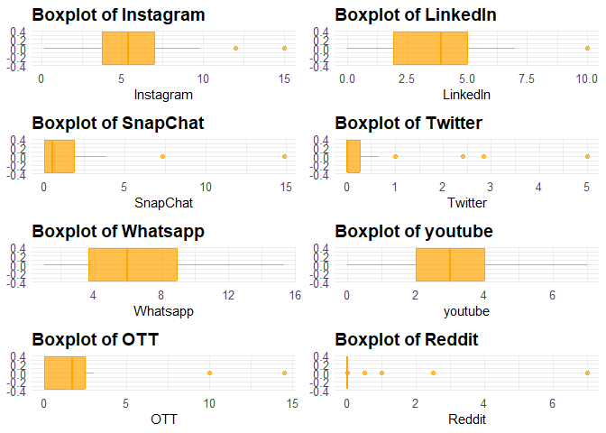

```r
# Subset the data to include only the required variables
names(social_media) <- c("character", "Instagram", "LinkedIn", "SnapChat",
                 "Twitter", "Whatsapp", "youtube",
                 "OTT", "Reddit","Trouble_falling_asleep","Mood_Productivity","Tired waking up in morning", "How you felt the entire week?")

selected_vars <- c("Instagram", "LinkedIn", "SnapChat",
                   "Twitter", "Whatsapp", "youtube",
                   "OTT", "Reddit")

boxplots <- lapply(selected_vars, function(var) {
  ggplot(social_media, aes_string(y = var)) +
    geom_boxplot(fill = "orange", color = "orange", alpha = 0.7) +
    labs(title = paste("Boxplot of", var), y = var) +
    theme_minimal() +
    theme(plot.title = element_text(size = 14, face = "bold"),
          axis.title.y = element_text(size = 12),
          axis.text = element_text(size = 10),
          legend.position = "none") +
    coord_flip()
})
gridExtra::grid.arrange(grobs = boxplots, ncol = 2)
```

```r
library(tidyr)
```

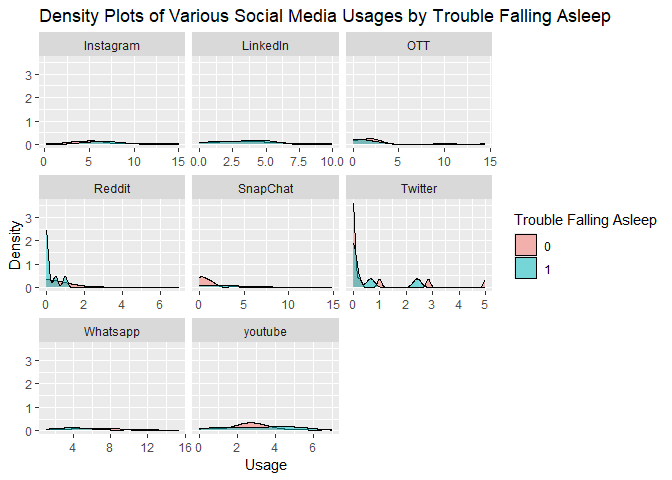

```r
names(social_media)[is.na(names(social_media))] <- "COl1"

# Reshape data into long format
social_media_long <- pivot_longer(social_media,
                                  cols = c(Instagram, LinkedIn, SnapChat,
                                           Twitter, Whatsapp, youtube,
                                           OTT, Reddit),
                                  names_to = "variable",
                                  values_to = "value")


ggplot(social_media_long, aes(x = value, fill = factor(Trouble_falling_asleep))) +
  geom_density(alpha = 0.5) +
  labs(title = "Density Plots of Various Social Media Usages by Trouble Falling Asleep",
       x = "Usage",
       y = "Density",
       fill = "Trouble Falling Asleep") +
  facet_wrap(~ variable, scales = "free_x", nrow = 3)
```

#### Correltion and Coefficient

```r
correlation_coefficient <- cor(social_media$Instagram, social_media$Trouble_falling_asleep)
print(correlation_coefficient)
```

```
## [1] 0.5053586
```

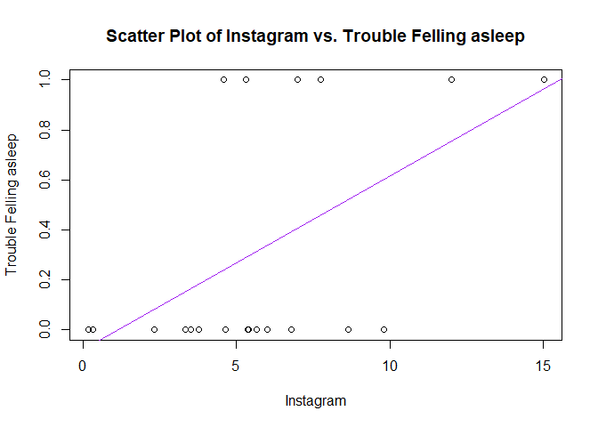

```r
plot(social_media$Instagram, social_media$Trouble_falling_asleep,
     xlab = "Instagram", ylab = "Trouble Felling asleep",
     main = "Scatter Plot of Instagram vs. Trouble Felling asleep")

abline(lm(social_media$Trouble_falling_asleep ~ social_media$Instagram), col = "purple")
```

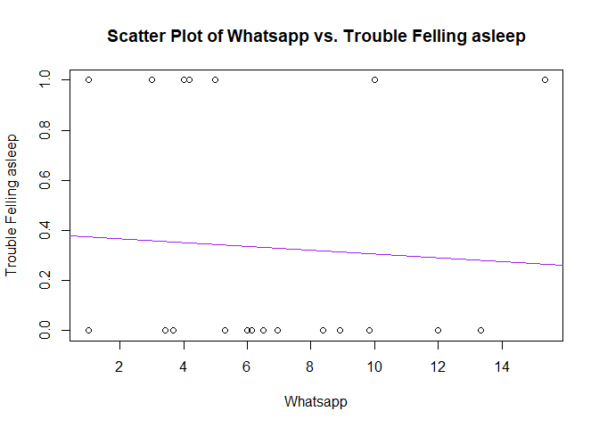

```r
plot(social_media$Whatsapp, social_media$Trouble_falling_asleep,
     xlab = "Whatsapp", ylab = "Trouble Felling asleep",
     main = "Scatter Plot of Whatsapp vs. Trouble Felling asleep")

abline(lm(social_media$Trouble_falling_asleep ~ social_media$Whatsapp), col = "purple")
```

```r
print(paste("Correlation Coefficient between Instagram and Trouble Felling asleep Duration:", correlation_coefficient))
```

```
## [1] "Correlation Coefficient between Instagram and Trouble Felling asleep Duration: 0.505358558539933"
```

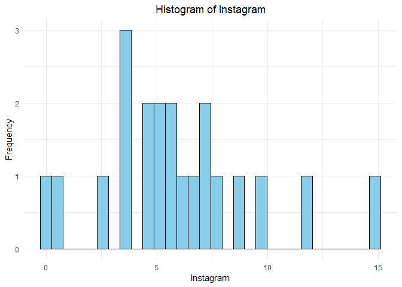

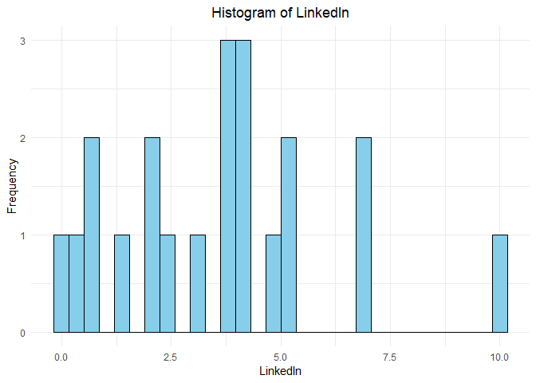

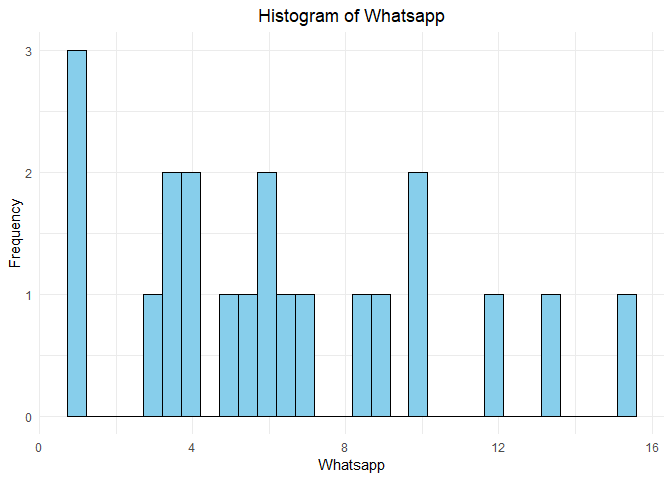

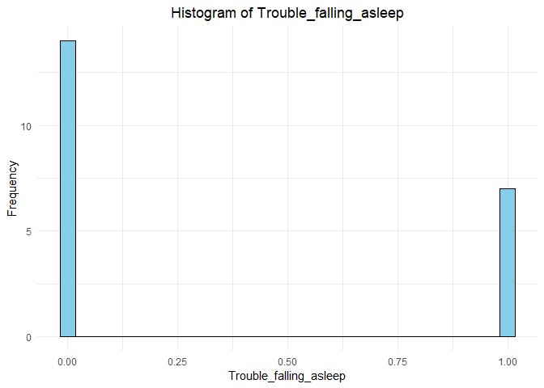

```r
num_vars <- c("Instagram", "LinkedIn", "Whatsapp", "Trouble_falling_asleep")

for (var in num_vars) {
  p <- ggplot(social_media, aes(x = social_media[[var]])) +
    geom_histogram(fill = "skyblue", color = "black") +
    labs(title = paste("Histogram of", var), x = var, y = "Frequency") +
    theme_minimal() +
    theme(plot.title = element_text(hjust = 0.5))
  print(p)
}
```

**How addicted are users generally to social media apps, and is this related to the fact that many report having difficulty falling asleep?**

```r
social_media$Social_Media_Addiction <- rowSums(social_media[, c("Instagram", "LinkedIn" , "Twitter", "Whatsapp" , "OTT", "Reddit")])

summary(social_media$Social_Media_Addiction)
```

```
##    Min. 1st Qu.  Median    Mean 3rd Qu.    Max.
##   1.167  14.417  18.500  19.442  24.000  44.317
```

```r
summary(social_media$Trouble_falling_asleep)
```

```
##    Min. 1st Qu.  Median    Mean 3rd Qu.    Max.
##  0.0000  0.0000  0.0000  0.3333  1.0000  1.0000
```

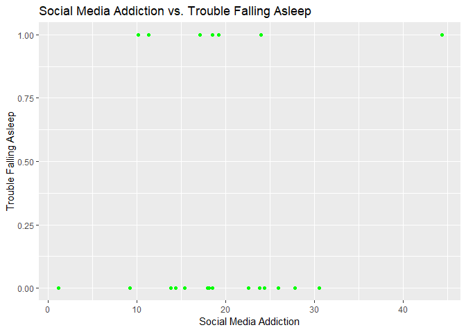

```r
# Scatter plot of social media addiction vs. trouble falling asleep
ggplot(social_media, aes(x = Social_Media_Addiction, y = Trouble_falling_asleep)) +
  geom_point(color = "green") +
  labs(title = "Social Media Addiction vs. Trouble Falling Asleep",
       x = "Social Media Addiction",
       y = "Trouble Falling Asleep")
```

**How much each user is addicted to a particular social networking app, and is there a connection between app addiction and reported difficulty falling asleep?**

```r
summary(social_media$Instagram)
```

```
##    Min. 1st Qu.  Median    Mean 3rd Qu.    Max.
##  0.1667  3.7667  5.3833  5.9230  7.0000 15.0167
```

```r
summary(social_media$Whatsapp)
```

```
##    Min. 1st Qu.  Median    Mean 3rd Qu.    Max.
##   1.000   3.667   6.000   6.430   8.917  15.350
```

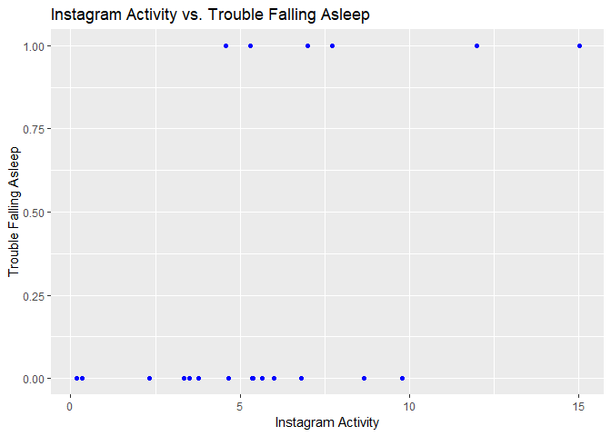

```r
ggplot(social_media, aes(x = Instagram, y = Trouble_falling_asleep)) +
  geom_point(color = "blue") +
  labs(title = "Instagram Activity vs. Trouble Falling Asleep",
       x = "Instagram Activity",
       y = "Trouble Falling Asleep")
```

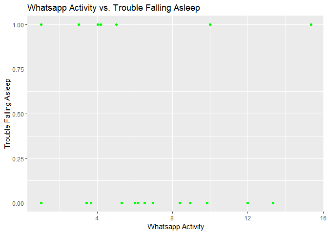

```r
ggplot(social_media, aes(x = Whatsapp , y = Trouble_falling_asleep)) +
  geom_point(color = "green") +
  labs(title = "Whatsapp Activity vs. Trouble Falling Asleep",
       x = "Whatsapp Activity",
       y = "Trouble Falling Asleep")
```

**Is there a pattern in the reported mood levels throughout the course of the week, and if so, how does this pattern connect to activity on social media?**

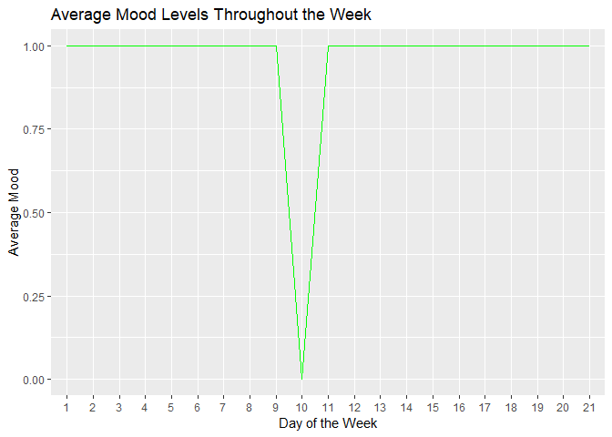

```r
n_rows <- nrow(social_media)
day_of_week <- factor(1:n_rows)
unique_days <- unique(day_of_week)

ggplot(social_media, aes(x = day_of_week, y = `Mood_Productivity`, group = 1)) +
  geom_line(color = "green") +
  labs(title = "Average Mood Levels Throughout the Week",
       x = "Day of the Week",
       y = "Average Mood")
```

```r
correlation_matrix <- cor(social_media[, c("Mood_Productivity", "Instagram", "LinkedIn", "Twitter", "Whatsapp", "youtube", "OTT", "Reddit")])

# Print correlation matrix
print(correlation_matrix)
```

```
##                   Mood_Productivity   Instagram     LinkedIn    Twitter
## Mood_Productivity       1.000000000  0.37498880  0.335447863  0.1029958
## Instagram               0.374988801  1.00000000  0.097056399 -0.1930565
## LinkedIn                0.335447863  0.09705640  1.000000000 -0.1300685
## Twitter                 0.102995756 -0.19305653 -0.130068464  1.0000000
## Whatsapp                0.308871917  0.37769615  0.228835623 -0.4958329
## youtube                -0.003621212  0.33000187  0.452197669 -0.1881777
## OTT                     0.153208032  0.26738122  0.185492527  0.5570740
## Reddit                  0.075429291 -0.07461553 -0.006992884  0.1649030
##                     Whatsapp      youtube       OTT       Reddit
## Mood_Productivity  0.3088719 -0.003621212 0.1532080  0.075429291
## Instagram          0.3776962  0.330001869 0.2673812 -0.074615529
## LinkedIn           0.2288356  0.452197669 0.1854925 -0.006992884
## Twitter           -0.4958329 -0.188177691 0.5570740  0.164902964
## Whatsapp           1.0000000  0.371685163 0.1336204 -0.134449660
## youtube            0.3716852  1.000000000 0.1605652  0.026399913
## OTT                0.1336204  0.160565234 1.0000000  0.232791099
## Reddit            -0.1344497  0.026399913 0.2327911  1.000000000
```